# R Workshop: Data Frames and Programming Structure

February 20, 2016

## Outline

- Creating Data Frames
- Matrix-Like Operations
- Merging Data Frames
- Applying Functions to Data Frames
- Programming Structure
- Where to get help

All files we need in this workshop can be found:  
https://github.com/Ying-Ju/Miami-DataFest-Workshops

## Creating Data Frames

## Example

```r
names = c('David', 'John', 'Mary')
quiz.1 = c(89, 93, 85)
quiz.2 = c(91, 88, 90)
Grade = data.frame(names, quiz.1, quiz.2, stringsAsFactors = TRUE)
Grade
```

```
##   names quiz.1 quiz.2
## 1 David     89     91
## 2  John     93     88
## 3  Mary     85     90
```

## Example

```r
Grade[[1]]
```

```
## [1] David John  Mary
## Levels: David John Mary
```

```r
Grade$quiz.1
```

```
## [1] 89 93 85
```

```r
Grade[,3]
```

```
## [1] 91 88 90
```

## Example (Reading a csv file)

```r
mypath <-'https://raw.githubusercontent.com/Ying-Ju/Miami-DataFest-Workshops/master/'
data1 <- paste(mypath,'tuition.csv', sep='')
tuition <- read.table(data1, header=TRUE, sep=",", as.is=FALSE)
dim(tuition)
```

```
## [1] 20  3
```

```r
names(tuition)
```

```
## [1] "private.U" "Public.UI" "Public.UO"
```

## Example (Filtering)

```r
tuition[tuition$Public.UO >= 8000,]
```

```
##   private.U Public.UI Public.UO
## 4     15688      2984      9766
## 7      9300      3338      8594
```

```r
subset(tuition, Public.UO >= 8000)
```

```
##   private.U Public.UI Public.UO
## 4     15688      2984      9766
## 7      9300      3338      8594
```

## Example (Dealing with missing values)

```r
newtuition = rbind(tuition[1:3,], c(12131, NA, 5331))
complete = newtuition[complete.cases(newtuition),]
mean(newtuition$Public.UI)
```

```
## [1] NA
```

```r
mean(newtuition$Public.UI, na.rm=TRUE)
```

```
## [1] 1752
```

## Matrix-Like Operations

## Example (Applying apply())

```r
apply(tuition, 2, median)
```

```
## private.U Public.UI Public.UO
##     12033      2021      6331
```

```r
apply(tuition, 2, mean)
```

```
## private.U Public.UI Public.UO
##  11794.75   2188.10   6368.10
```

## Example (Merging Data Frames)

```r
Grade1 = data.frame(students = c('David', 'Gabby', 'Mary'),
                    quiz.3=c(88, 92, 85),
                    stringsAsFactors=TRUE)
merge(Grade, Grade1, by.x="names", by.y="students")
```

```
##   names quiz.1 quiz.2 quiz.3
## 1 David     89     91     88
## 2  Mary     85     90     85
```

```r
lapply(Grade[,2:3], mean)
```

```
## $quiz.1
## [1] 89
##
## $quiz.2
## [1] 89.66667
```

## Example (Applying tapply())

```r
Grade.example <- data.frame(
student <- 1:100,
grade <- rnorm(100, mean=70, sd=15),
gender <- gl(2, 50, labels=c("Male", "Female")))
summary(Grade.example)
```

```
##  student....1.100 grade....rnorm.100..mean...70..sd...15.
##  Min.   :  1.00   Min.   : 30.13
##  1st Qu.: 25.75   1st Qu.: 61.85
##  Median : 50.50   Median : 71.39
##  Mean   : 50.50   Mean   : 71.47
##  3rd Qu.: 75.25   3rd Qu.: 81.57
##  Max.   :100.00   Max.   :123.98
##  gender....gl.2..50..labels...c..Male....Female...
##  Male  :50
##  Female:50
##
##
##
##
```

- In this data set, we generate 100 students' grades by using the normal distribution with mean 70 and the standard deviation 15
- gl is a function to generate factor levels

## Example

```r
grade.mean = tapply(Grade.example$grade, Grade.example$gender, mean)
grade.sd = tapply(Grade.example$grade, Grade.example$gender, sd)
grade.quantile = tapply(Grade.example$grade, Grade.example$gender,
                        function(x) quantile(x, c(0.05, 0.95)))
CI.left = c(grade.quantile$Male[1], grade.quantile$Female[1])
CI.right = c(grade.quantile$Male[2], grade.quantile$Female[2])
cbind(grade.mean, grade.sd, CI.left, CI.right)
```

```
##        grade.mean grade.sd  CI.left CI.right
## Male     72.93566 14.36779 55.49653 95.89688
## Female   70.00112 17.43972 44.07097 92.28991
```

## Applying Logistic Regression Models

\[P(Y=1|X=t)=\frac{1}{1+\exp[-(\beta_0+\beta_1t)]}\]

```r
aba <- read.table(paste(mypath,'ABALONE_data.txt', sep=''), sep = ",", header=T)
abamf <- aba[aba$Gender != "I",]
lftn <- function(clmn){
  glm(abamf$Gender~clmn, family = binomial)$coef
}
loall <- sapply(abamf[,-1],lftn)
loall
```

```
##                Length  Diameter    Height Whole.weight Shucked.weight
## (Intercept)  1.275832  1.289130  1.027872    0.4300827      0.2855054
## clmn        -1.962613 -2.533227 -5.643495   -0.2688070     -0.2941351
##             Viscera.weight Shell.weight       Rings
## (Intercept)      0.4829153    0.5103942  0.64823569
## clmn            -1.4647507   -1.2135496 -0.04509376
```

## How to write a function in R

-Example: \(f(x,y,z)=a\cdot x+b \cdot y+c\)

```r
myfunction <- function(x, y, c){
  c[1]*x+c[2]*y+c[3]
}
myfunction(2, 1, c(4, 1, 9))
```

```
## [1] 18
```

- Use the comment: rm(list=ls()) to clean the workspace
- R takes only the last line of the function to be the return value

## Programming Structure in R

## Programming Structure in R

- for
- while
- ifelse statment
- if statement
- repeat

## Example: for loop

- Find the sum of \(1+2+\cdots+n\).  
  How to start?

```r
n <- 100
total.loop <- 0
for (i in 1:n) total.loop <- total.loop + i
total.loop
```

```
## [1] 5050
```

- **Try**: Put the loop in a function with an input value \(n\) and return the sum.

## Example: while loop

- Find the sum of \(1+2+\cdots+n\).

```r
n <- 100
total.while <- 0
k <- 0
while (k<n){
  k <- k + 1
  total.while <- total.while + k
}
total.while
```

```
## [1] 5050
```

- **Question**: What's the difference between if and while loops? When should we use if / while statments?

## Example: if statement

- Write a simple loop to find all even numbers and odd numbers in [15, 30] and print the statment "n is an even / odd number."

```r
for (i in seq(15, 30)){
  if (i %% 2 == 0){
  print(paste(i, ' is an even number.'))
  }else{
    print(paste(i, ' is an odd number.'))
  }
}
```

## Example: ifelse statment

```r
  mynumber <- seq(15, 30)
  evenorodd <- ifelse(mynumber%%2==0, " is an even number.", " is an odd number.")
  for (i in 1:length(evenorodd)){
    print(paste(mynumber[i], evenorodd[i]))
  }
```

- **Question**: When should we use if / ifelse statements?

## Example: repeat

- Find the sum of \(1+2+\cdots+n\).

```r
x <- 0
total.repeat <- 0
repeat {
   x <- x+1
   total.repeat <- total.repeat + x
   if (x == 100){
       break
   }
}
total.repeat
```

```
## [1] 5050
```

## Can a function call itself?

Yes! It is called a **recursive function**. (A function with a function)  
Example: Compute \(1\times 2+ 2\times 3 + \ldots + n\times (n+1)\).

```r
Myfun_rec <- function(n){
  if (n==1){
    return(2)
  } else {
    return(n*(n+1)+Myfun_rec(n-1))
  }
}
```

## An example for computing fractals from iterated function systems

- http://krazydad.com/bestiary/bestiary_fern.html

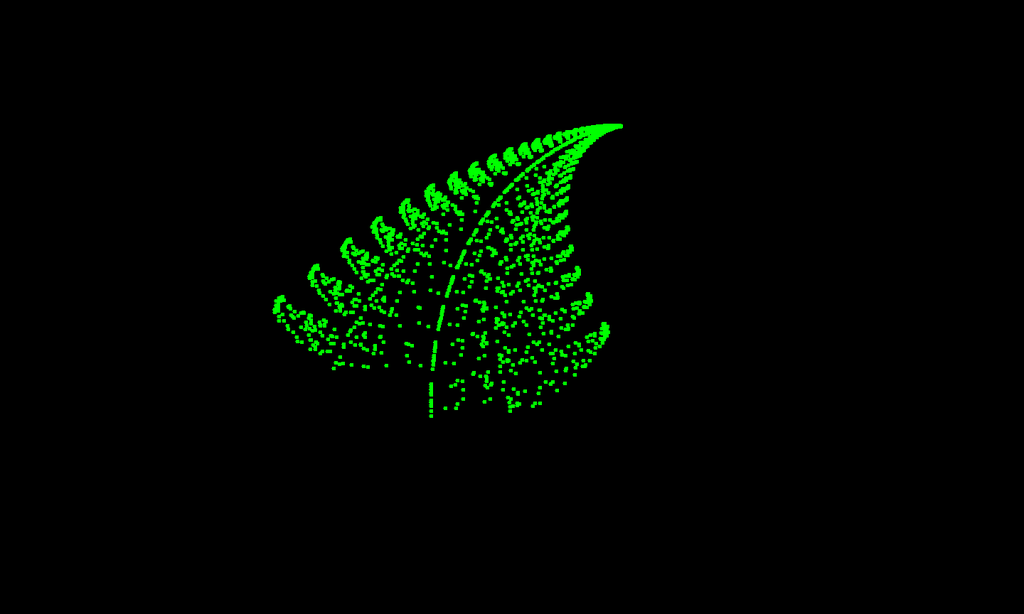

## Where to get help ?

1. To see documentation on any **function** in R, execute `?data.frame`, `?apply`, etc.
2. Go: http://www.orgs.miamioh.edu/datafest/index.html/resource.html
3. Ask people if you can!
4. Google it! (Better way to learn coding!)